# EDA Assignment

YIFAN ZHAO

February 18, 2019

Link to github project: https://github.com/Yzhao7/DataAnalytics-YZ/tree/master/project

1. Setup the question Refine the problem, the following questions reflect the process of refining the question:
1. How does variable ‘price’ related to the parameters of bike vendors?
2. The variable ‘price’ has a negative relationship with the parameters of each bike vendor
3. Does vairable ‘price’ has a negative relationship with the parameters of each bike vendor? *4) Does variable ‘price’ has a negative relationship with the parameter of vendor ‘Ann.Arbor.Speed’ (my final question)
2. Describe the data The data has 1 row of headers, 97 obeserving rows, and 35 variables. The following is a description of the variables:

‘model’ - bike model ‘category1’ - category of bike models ‘category2’ - sub-category of bike models under category1 ‘frame’ - the texture of the bike frame ‘price’ - the price of each model, in $ the bike vendor names (such as ‘Albuquerque Cycles’, ‘Ann Arbor Speed’, ‘Austin Cruisers’..) - the parameter of each vendor by bike models (I am not quite sure what these variables represent, so I will just call them parameters of each model by vendor), it looks like these parameters has some kind of correlation or relationship with the model or more specifically, model price.

At this point, I want to change the question to ‘Does variable ’price’ has a negative relationship with the parameter of vendor ‘Ann.Arbor.Speed’?’

3. Explore the data

```r
bike_vendor <- read.csv("C:/HU/Late Fall 2018/ANLY506/EDA Assignment/bikeVendors.csv")
##
summary(bike_vendor)
```

```
##                  model       category1               category2
##  Bad Habit 1        : 1   Mountain:51   Elite Road        :21
##  Bad Habit 2        : 1   Road    :46   Cross Country Race:19
##  Beast of the East 1: 1                 Endurance Road    :16
##  Beast of the East 2: 1                 Trail             :13
##  Beast of the East 3: 1                 Sport             : 9
##  CAAD Disc Ultegra  : 1                 Over Mountain     : 8
##  (Other)            :91                 (Other)           :11
##       frame        price       Albuquerque.Cycles Ann.Arbor.Speed
##  Aluminum:40   Min.   :  415   Min.   :0.000000   Min.   :0.000000
##  Carbon  :57   1st Qu.: 1950   1st Qu.:0.003497   1st Qu.:0.003322
##                Median : 3200   Median :0.006993   Median :0.009967
##                Mean   : 3954   Mean   :0.010309   Mean   :0.010309
##                3rd Qu.: 5330   3rd Qu.:0.013986   3rd Qu.:0.014950
##                Max.   :12790   Max.   :0.048951   Max.   :0.033223
##
##  Austin.Cruisers    Cincinnati.Speed   Columbus.Race.Equipment
##  Min.   :0.000000   Min.   :0.000000   Min.   :0.000000
##  1st Qu.:0.004065   1st Qu.:0.002558   1st Qu.:0.005076
##  Median :0.008130   Median :0.010230   Median :0.010152
##  Mean   :0.010309   Mean   :0.010309   Mean   :0.010309
##  3rd Qu.:0.016260   3rd Qu.:0.015345   3rd Qu.:0.012690
##  Max.   :0.052846   Max.   :0.033248   Max.   :0.038071
##
##  Dallas.Cycles      Denver.Bike.Shop    Detroit.Cycles
##  Min.   :0.000000   Min.   :0.0004346   Min.   :0.000000
##  1st Qu.:0.004274   1st Qu.:0.0073881   1st Qu.:0.005952
##  Median :0.008547   Median :0.0104302   Median :0.009921
##  Mean   :0.010309   Mean   :0.0103093   Mean   :0.010309
##  3rd Qu.:0.012821   3rd Qu.:0.0134724   3rd Qu.:0.013889
##  Max.   :0.042735   Max.   :0.0256410   Max.   :0.029762
##
##  Indianapolis.Velocipedes Ithaca.Mountain.Climbers Kansas.City.29ers
##  Min.   :0.000000         Min.   :0.000000         Min.   :0.0002881
##  1st Qu.:0.003135         1st Qu.:0.002373         1st Qu.:0.0072025
##  Median :0.006270         Median :0.010285         Median :0.0100835
##  Mean   :0.010309         Mean   :0.010309         Mean   :0.0103093
##  3rd Qu.:0.015674         3rd Qu.:0.016614         3rd Qu.:0.0132527
##  Max.   :0.050157         Max.   :0.027690         Max.   :0.0247767
##
```

[output cut: 41 more lines]

```
##  Min.   :0.000000       Min.   :0.000000       Min.   :0.000000
##  1st Qu.:0.002674       1st Qu.:0.000000       1st Qu.:0.000000
##  Median :0.008021       Median :0.007812       Median :0.004854
##  Mean   :0.010309       Mean   :0.010309       Mean   :0.010309
##  3rd Qu.:0.016043       3rd Qu.:0.015625       3rd Qu.:0.014563
##  Max.   :0.042781       Max.   :0.054688       Max.   :0.048544
##
##  Wichita.Speed
##  Min.   :0.000000
##  1st Qu.:0.003945
##  Median :0.009862
##  Mean   :0.010309
##  3rd Qu.:0.015779
##  Max.   :0.047337
##
```

```r
##
str(bike_vendor)
```

```
## 'data.frame':    97 obs. of  35 variables:
##  $ model                       : Factor w/ 97 levels "Bad Habit 1",..: 1 2 3 4 5 6 7 8 9 10 ...
##  $ category1                   : Factor w/ 2 levels "Mountain","Road": 1 1 1 1 1 2 2 2 2 2 ...
##  $ category2                   : Factor w/ 9 levels "Cross Country Race",..: 8 8 8 8 8 3 3 3 3 3 ...
##  $ frame                       : Factor w/ 2 levels "Aluminum","Carbon": 1 1 1 1 1 1 1 1 1 1 ...
##  $ price                       : int  3200 2660 2770 2130 1620 2660 1680 5860 1950 4260 ...
##  $ Albuquerque.Cycles          : num  0.01748 0.00699 0.01049 0.01049 0.0035 ...
##  $ Ann.Arbor.Speed             : num  0.00664 0.00997 0.01495 0.00997 0.00332 ...
##  $ Austin.Cruisers             : num  0.00813 0.00407 0.00813 0.00813 0 ...
##  $ Cincinnati.Speed            : num  0.00512 0 0 0 0 ...
##  $ Columbus.Race.Equipment     : num  0.01015 0 0 0.00508 0.00254 ...
##  $ Dallas.Cycles               : num  0.01282 0.01709 0.00427 0.00427 0.00427 ...
##  $ Denver.Bike.Shop            : num  0.0117 0.0139 0.0183 0.0152 0.0169 ...
##  $ Detroit.Cycles              : num  0.00992 0.01587 0.0119 0.00595 0.0119 ...
##  $ Indianapolis.Velocipedes    : num  0.00627 0.00313 0.0094 0.0094 0 ...
```

[output cut: 21 more lines]

```r
## take a look at the beginning of the dataset to have a good idea of what the dataset look like
head(bike_vendor)
```

```
##                 model category1  category2    frame price
## 1         Bad Habit 1  Mountain      Trail Aluminum  3200
## 2         Bad Habit 2  Mountain      Trail Aluminum  2660
## 3 Beast of the East 1  Mountain      Trail Aluminum  2770
## 4 Beast of the East 2  Mountain      Trail Aluminum  2130
## 5 Beast of the East 3  Mountain      Trail Aluminum  1620
## 6   CAAD Disc Ultegra      Road Elite Road Aluminum  2660
##   Albuquerque.Cycles Ann.Arbor.Speed Austin.Cruisers Cincinnati.Speed
## 1        0.017482517     0.006644518     0.008130081       0.00511509
## 2        0.006993007     0.009966777     0.004065041       0.00000000
## 3        0.010489510     0.014950166     0.008130081       0.00000000
## 4        0.010489510     0.009966777     0.008130081       0.00000000
## 5        0.003496503     0.003322259     0.000000000       0.00000000
## 6        0.013986014     0.026578073     0.020325203       0.01534527
##   Columbus.Race.Equipment Dallas.Cycles Denver.Bike.Shop Detroit.Cycles
```

[output cut: 55 more lines]

```r
## take a look at the end of the dataset to see if eveything is okay because some dataset has rows that are omitted at the end
tail(bike_vendor)
```

```
##               model category1     category2    frame price
## 92          Trail 4  Mountain         Sport Aluminum   980
## 93          Trail 5  Mountain         Sport Aluminum   815
## 94 Trigger Carbon 1  Mountain Over Mountain   Carbon  8200
## 95 Trigger Carbon 2  Mountain Over Mountain   Carbon  5970
## 96 Trigger Carbon 3  Mountain Over Mountain   Carbon  3730
## 97 Trigger Carbon 4  Mountain Over Mountain   Carbon  3200
##    Albuquerque.Cycles Ann.Arbor.Speed Austin.Cruisers Cincinnati.Speed
## 92        0.017482517     0.003322259     0.008130081      0.002557545
## 93        0.010489510     0.011627907     0.008130081      0.000000000
## 94        0.006993007     0.000000000     0.000000000      0.010230179
## 95        0.003496503     0.000000000     0.000000000      0.007672634
## 96        0.006993007     0.000000000     0.000000000      0.010230179
## 97        0.006993007     0.011627907     0.016260163      0.020460358
##    Columbus.Race.Equipment Dallas.Cycles Denver.Bike.Shop Detroit.Cycles
```

[output cut: 55 more lines]

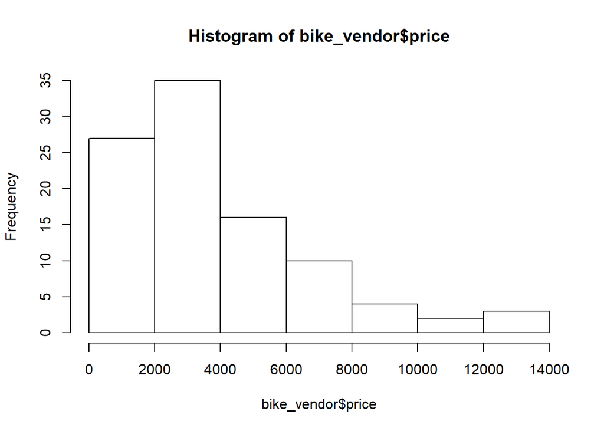

```r
## Plot variable price on histogram
hist(bike_vendor$price)
```

```r
## Get the column names
names(bike_vendor)
```

```
##  [1] "model"                        "category1"
##  [3] "category2"                    "frame"
##  [5] "price"                        "Albuquerque.Cycles"
##  [7] "Ann.Arbor.Speed"              "Austin.Cruisers"
##  [9] "Cincinnati.Speed"             "Columbus.Race.Equipment"
## [11] "Dallas.Cycles"                "Denver.Bike.Shop"
## [13] "Detroit.Cycles"               "Indianapolis.Velocipedes"
## [15] "Ithaca.Mountain.Climbers"     "Kansas.City.29ers"
## [17] "Las.Vegas.Cycles"             "Los.Angeles.Cycles"
## [19] "Louisville.Race.Equipment"    "Miami.Race.Equipment"
## [21] "Minneapolis.Bike.Shop"        "Nashville.Cruisers"
## [23] "New.Orleans.Velocipedes"      "New.York.Cycles"
## [25] "Oklahoma.City.Race.Equipment" "Philadelphia.Bike.Shop"
## [27] "Phoenix.Bi.peds"              "Pittsburgh.Mountain.Machines"
## [29] "Portland.Bi.peds"             "Providence.Bi.peds"
## [31] "San.Antonio.Bike.Shop"        "San.Francisco.Cruisers"
## [33] "Seattle.Race.Equipment"       "Tampa.29ers"
## [35] "Wichita.Speed"
```

```r
## check for missing values
is.na(bike_vendor)
```

[output not shown]

[output cut: 1063 more lines]

4. Visualization

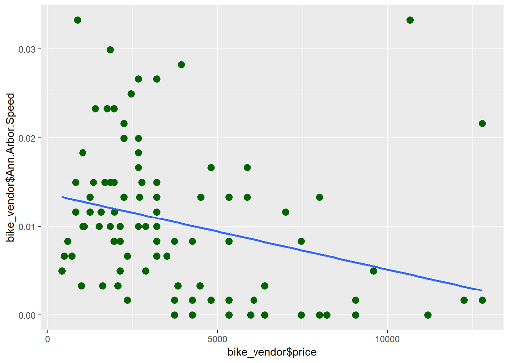

```r
library(ggplot2)
p <- ggplot(bike_vendor, aes(bike_vendor$price, bike_vendor$Ann.Arbor.Speed))
p + geom_point(colour="dark green", size = 3)+
  geom_smooth(method = "lm", se = FALSE)
```

```r
## we can see price and Ann.Arbor.Speed parameter has a negative relationship

relationship <-lm(price ~ Ann.Arbor.Speed, data = bike_vendor)
relationship
```

```
##
## Call:
## lm(formula = price ~ Ann.Arbor.Speed, data = bike_vendor)
##
## Coefficients:
##     (Intercept)  Ann.Arbor.Speed
##            4971           -98700
```

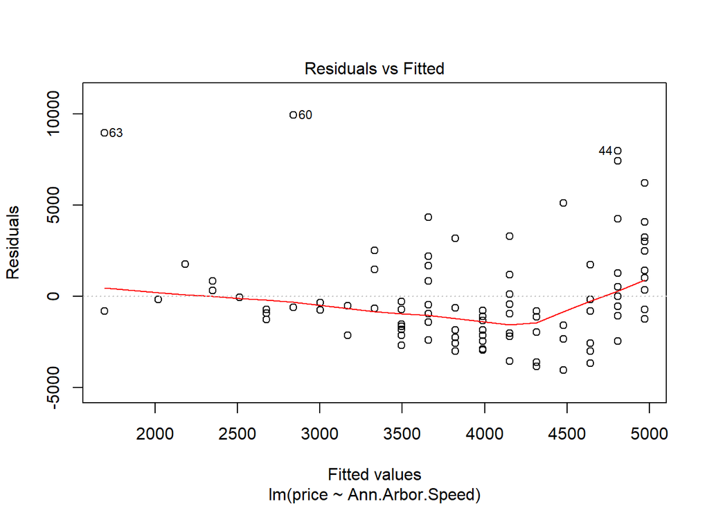

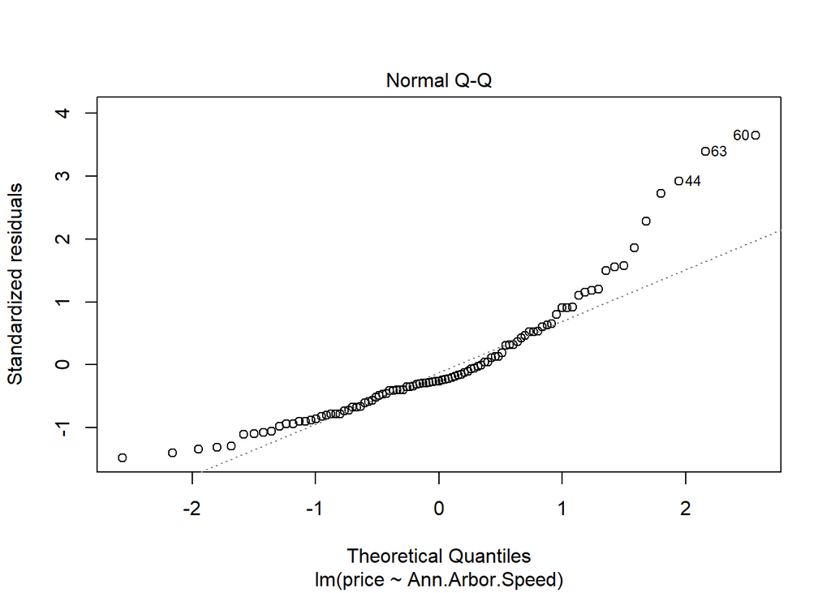

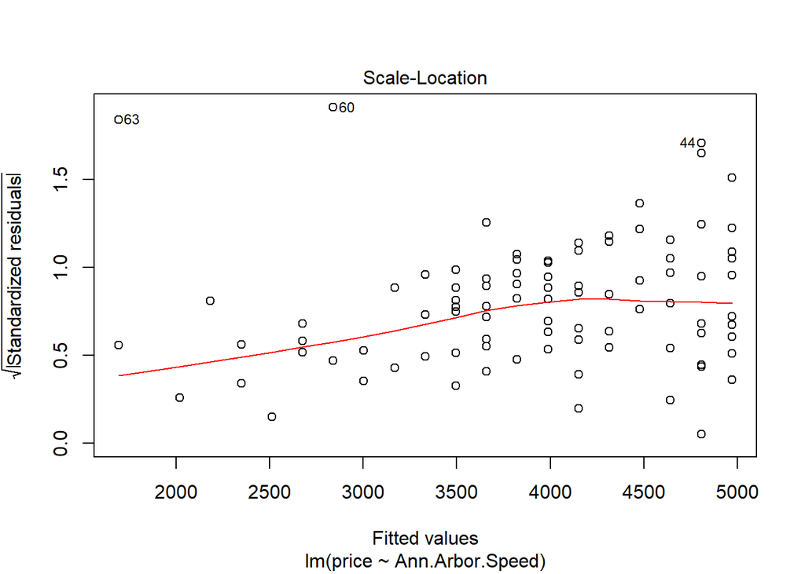

```r
plot(relationship)
```

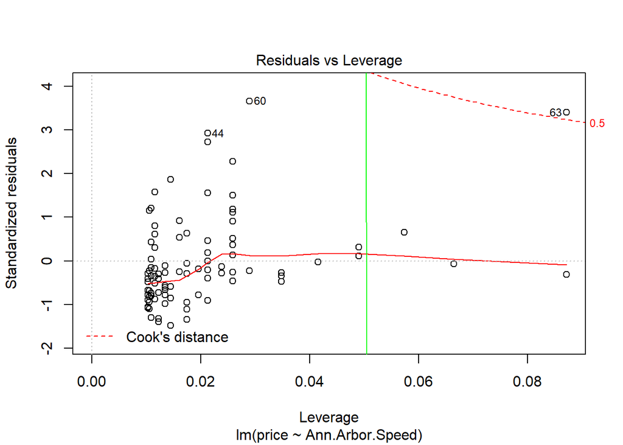

```r
abline(relationship, col = "green")
```

From the plots above, we can see that in the 1st plot, we can see a parabola-like pattern, which is not good enough.

On normal Q-Q Plot, we can see at the end of the line, the plot deviates from the straight dashed line. This means the residual is not entirely normally distributed.

5. Report findings, provide answer to the question asked in the first step of EDA

To answer the question, the variable ‘price’ has a negative relationship with the parameter of vendor ‘Ann.Arbor.Speed’ and the assumptions are tested.